# Satellite Imagery Based Property Valuation: Final Report

**Enrollment No:** 24119021

## 1. Overview

This project develops a **Multimodal Regression Pipeline** to predict property values by integrating tabular housing data with satellite imagery. By capturing visual environmental features (greenery, density, proximity to water), the model aims to improve valuation accuracy beyond traditional hedonic pricing models.

## 2. Exploratory Data Analysis (EDA)

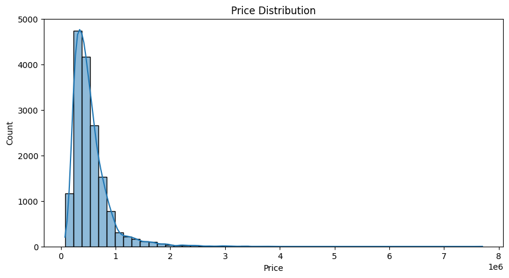

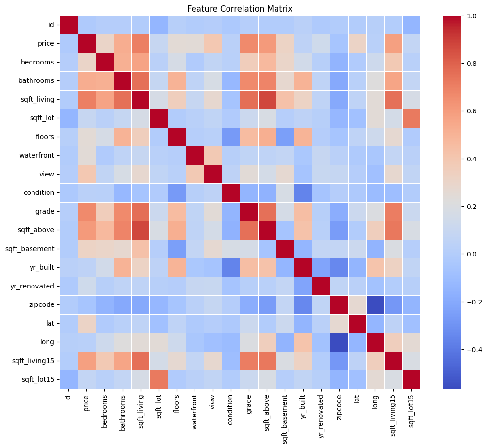

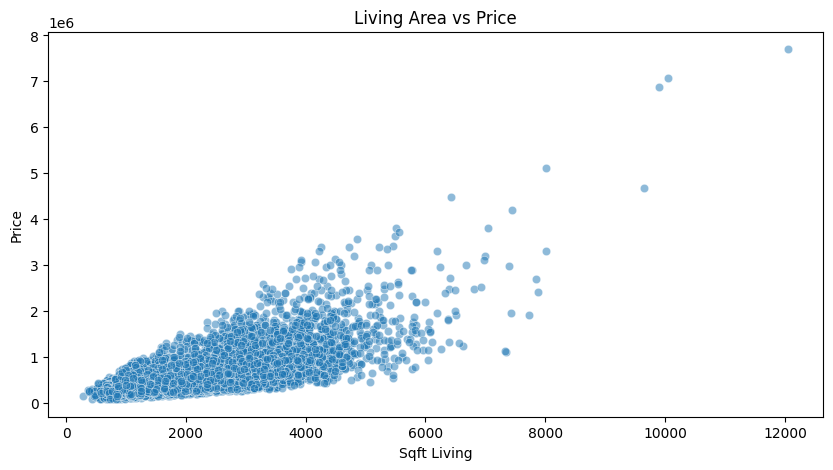

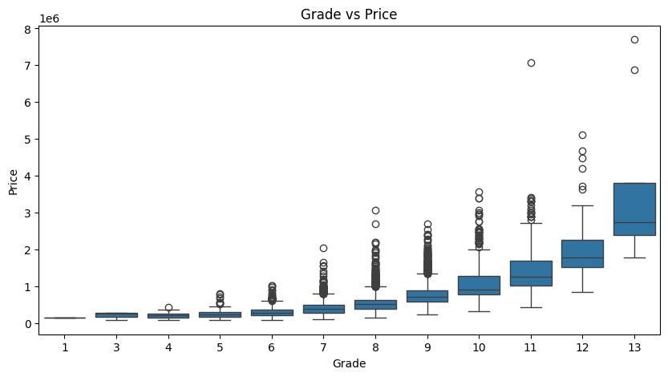

```python
import pandas as pd
import seaborn as sns
import matplotlib.pyplot as plt
import cv2
import os
import numpy as np
from sklearn.linear_model import LinearRegression
from sklearn.model_selection import train_test_split
from sklearn.preprocessing import StandardScaler
from sklearn.metrics import mean_squared_error, r2_score

train_df = pd.read_excel('train.xlsx')

# 1. Price Distribution
plt.figure(figsize=(10, 5))
sns.histplot(train_df['price'], bins=50, kde=True)
plt.title('Price Distribution')
plt.xlabel('Price')
plt.show()

# 2. Correlation Matrix
plt.figure(figsize=(12, 10))
# Select only numerical columns for correlation
numerical_df = train_df.select_dtypes(include=[np.number])
corr_matrix = numerical_df.corr()
sns.heatmap(corr_matrix, annot=False, cmap='coolwarm', linewidths=0.5)
plt.title('Feature Correlation Matrix')
plt.show()

# 3. Sqft Living vs Price
plt.figure(figsize=(10, 5))
sns.scatterplot(x='sqft_living', y='price', data=train_df, alpha=0.5)
plt.title('Living Area vs Price')
plt.xlabel('Sqft Living')
plt.ylabel('Price')
plt.show()

# 4. Grade vs Price
plt.figure(figsize=(10, 5))
sns.boxplot(x='grade', y='price', data=train_df)
plt.title('Grade vs Price')
plt.xlabel('Grade')
plt.ylabel('Price')
plt.show()
```

### Sample Satellite Imagery

Below are samples of the satellite images used for training.

[figure not shown]

```python
IMAGE_DIR = "satellite_images"
images = [f for f in os.listdir(IMAGE_DIR) if f.endswith('.jpg')][:5]

plt.figure(figsize=(15, 5))
for i, img_name in enumerate(images):
    path = os.path.join(IMAGE_DIR, img_name)
    img = cv2.imread(path)
    if img is not None:
        img = cv2.cvtColor(img, cv2.COLOR_BGR2RGB)
        plt.subplot(1, 5, i+1)
        plt.imshow(img)
        plt.axis('off')
plt.show()
```

## 3. Methodology & Architecture

We utilized a **Fusion Network** that combines two branches:

### Architecture Diagram

```
graph LR
    A[Tabular Data] --> B(MLP Branch);
    C[Satellite Image] --> D(CNN Branch);
    B --> E{Concatenation};
    D --> E;
    E --> F[Dense Layers];
    F --> G[Price Prediction];
```

1. **Tabular Branch:** A Multi-Layer Perceptron (MLP) processes features like `sqft_living`, `grade`, `bedrooms`.
2. **Image Branch:** A Convolutional Neural Network (CNN) extracts visual embeddings from 224x224 satellite images.
3. **Fusion Layer:** Features are concatenated and passed through dense layers to predict `price`.

## 4. Model Explainability (Grad-CAM)

```python
import tensorflow as tf

# Load Model
try:
    model = tf.keras.models.load_model('multimodal_model.h5')

    # Grad-CAM Logic
    def make_gradcam_heatmap(img_array, model, last_conv_layer_name, pred_index=None):
        grad_model = tf.keras.models.Model(
            [model.inputs[0], model.inputs[1]], [model.get_layer(last_conv_layer_name).output, model.output]
        )
        with tf.GradientTape() as tape:
            last_conv_layer_output, preds = grad_model([img_array[0], img_array[1]])
            if pred_index is None:
                pred_index = 0
            class_channel = preds[:, pred_index]
        grads = tape.gradient(class_channel, last_conv_layer_output)
        pooled_grads = tf.reduce_mean(grads, axis=(0, 1, 2))
        last_conv_layer_output = last_conv_layer_output[0]
        heatmap = last_conv_layer_output @ pooled_grads[..., tf.newaxis]
        heatmap = tf.squeeze(heatmap)
        heatmap = tf.maximum(heatmap, 0) / tf.math.reduce_max(heatmap)
        return heatmap.numpy()

    # Find Conv Layer
    last_conv_layer = None
    for layer in model.layers:
        if 'conv2d' in layer.name:
            last_conv_layer = layer.name

    # Load a sample image
    if len(images) > 0:
        sample_path = os.path.join(IMAGE_DIR, images[0])
        img = cv2.imread(sample_path)
        img = cv2.resize(img, (224, 224)) / 255.0
        img_input = np.expand_dims(img, axis=0)
        # Dummy numerical input
        num_input = np.zeros((1, 17))

        # Only run if we found a conv layer
        if last_conv_layer:
             heatmap = make_gradcam_heatmap([num_input, img_input], model, last_conv_layer)

             plt.figure(figsize=(10, 5))
             plt.subplot(1, 2, 1)
             plt.imshow(cv2.cvtColor(cv2.imread(sample_path), cv2.COLOR_BGR2RGB))
             plt.title('Satellite Image')
             plt.subplot(1, 2, 2)
             plt.imshow(heatmap)
             plt.title('Activation Map')
             plt.show()
except Exception as e:
    print(f"Could not load model or generate Grad-CAM: {e}")
```

```
Could not load model or generate Grad-CAM: Could not deserialize 'keras.metrics.mse' because it is not a KerasSaveable subclass
```